# Understanding some ipyrad outputs

J. Ignacio Lucas Lledó

2022-12-16

## Introduction

The typical analysis of ddRAD-seq or RAD-seq data ends up in a VCF that only includes polymorphic sites. Excluding from the VCF the sites that are invariable saves a lot of disk space. However, the heterozygosity is only comparable among samples, and meaningful in terms of model parameters, if it is calculated among a representative set of loci. Excluding monomorphic and doubtful loci introduces a bias. Also, we are interested in the fraction of monomorphic sites, as it is part of the allele frequency spectrum (AFS).

My goal in this folder was to determine what is the best measure of heterozigosity we can get from ipyrad, and how ipyrad parameters can affect the estimates. The one parameter in ipyrad that concerned me the most was the *clustering threshold*, which determines how similar two reads must be to be considered orthologs in a *de novo* analysis.

Another potential source of bias is the fact that some species are much closer related to the reference genome (*C. steinmanni*, De-Kayne et al. (2022)) than others. I was afraid that fewer clusters would be found in the most distant species.

In order to check these efects and gain confidence in the results from ipyrad, I decided to run ipyrad on only three samples: THU086 (*C. steinmanni*), and two representatives of the most distant clades: LAN103 and SUO105.

## Estimates of heterozygosity

There are two estimates of heterozygosity per sample produced by ipyrad. First, step 4 uses a maximum-likelihood method to simultaneously estimate heterozygosity and sequencing error rate over all clusters. Then, step 5 infer genotypes and counts the number of heterozygous sites per sample. Below I use this second, count-based heterozygosity that depends on the accuracy of the genotypes. It is visibly lower than the ML estimate, suggesting that it could be underestimating the true heterozigosity. But it is based on a heavily filtered subset of loci with decent coverage.

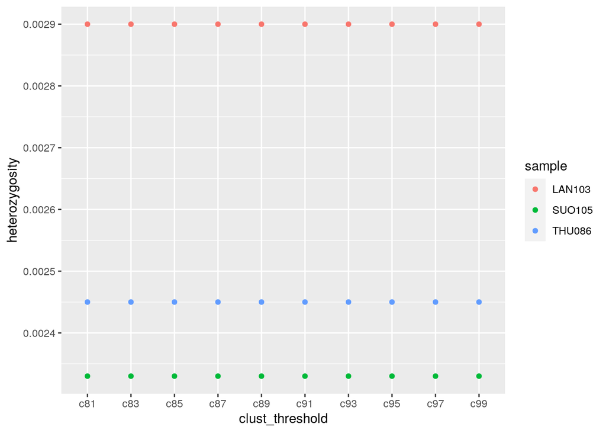

```r
library(ggplot2)
summary1 <- read.table('summary.txt', header = TRUE)
ggplot(data = summary1, mapping = aes(x = clust_threshold,
                                      y = heterozygosity,
                                      color = sample)) +
  geom_point()
```

The first conclusion is that the clustering threshold does not affect heterozygosity (nor the number of clusters), because the analysis is not a *de novo* assembly, but an assembly using a reference genome. I should have expected that clustering threshold was not going to affect the within-sample *clustering* step (step 3).

## Number of clusters (a.k.a *loci*)

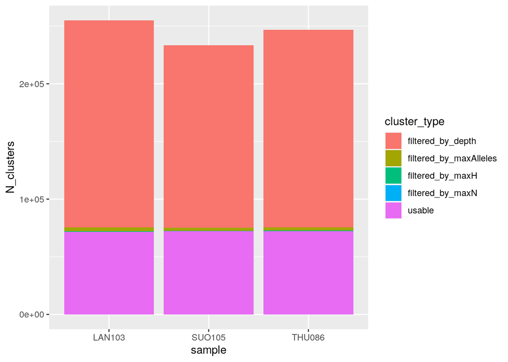

```r
library(tidyr)
summary2 <- summary1[summary1$clust_threshold == 'c93', ]
summary2$usable <- summary2$clusters_total -
                   summary2$filtered_by_depth -
                   summary2$filtered_by_maxAlleles -
                   summary2$filtered_by_maxH -
                   summary2$filtered_by_maxN
summary2 <- pivot_longer(summary2,
                         cols = c('filtered_by_depth',
                                  'filtered_by_maxAlleles',
                                  'filtered_by_maxH',
                                  'filtered_by_maxN',
                                  'usable'),
                         names_to = 'cluster_type',
                         values_to = 'N_clusters')
ggplot(summary2, aes(x=sample, y=N_clusters, fill=cluster_type)) +
  geom_bar(stat='identity')
```

If samples more distantly related to the reference genome had had a lower mapping success, not only the average cluster depth would have been lower, but the proportion of clusters filtered for that reason could have been higher. But it is not the case.

## Mapping quality

Let’s take a look at the mapping quality.

```r
library(plyr)
# mappingQuality.txt contains counts of reads with mapping qualities
# shown in the first column. Columns 2 to 4 are the three samples:
#   MAPQ    THU086  LAN103  SUO105
#   0       1184253 1369975 1591195
#   1       24849   34668   31628
#   2       23262   29559   30127
#   3       28941   37707   38154
#   4       26104   35555   33458
#   ...

mapq <- read.table('mappingQuality.txt', header = TRUE)

# I need a suffix in the column names to pivot the table longer
names(mapq)[2:4] <- paste0(names(mapq)[2:4], "_numReads")

# I add the columns of the proportion of reads with increasing
# mapping qualities. Note, the code does not assume sample names.
mapq[, ncol(mapq) + 1] <- mapq[,2] / sum(mapq[,2])
mapq[, ncol(mapq) + 1] <- mapq[,3] / sum(mapq[,3])
mapq[, ncol(mapq) + 1] <- mapq[,4] / sum(mapq[,4])

# And name the columns conveniently for pivoting:
names(mapq)[5:7] <- sub("numReads", "proportion", names(mapq)[2:4])
tail(mapq)
```

```
##    MAPQ THU086_numReads LAN103_numReads SUO105_numReads THU086_proportion
## 56   55           23936           32443           28463       0.001535259
## 57   56           27429           35089           34105       0.001759301
## 58   57           46496           54083           50038       0.002982262
## 59   58           21917           30062           32251       0.001405760
## 60   59           48268           58644           54396       0.003095918
## 61   60        11943776        12765910        13104560       0.766076000
##    LAN103_proportion SUO105_proportion
## 56       0.001891731       0.001618116
## 57       0.002046018       0.001938862
## 58       0.003153546       0.002844650
## 59       0.001752897       0.001833463
## 60       0.003419495       0.003092402
## 61       0.744372270       0.744991590
```

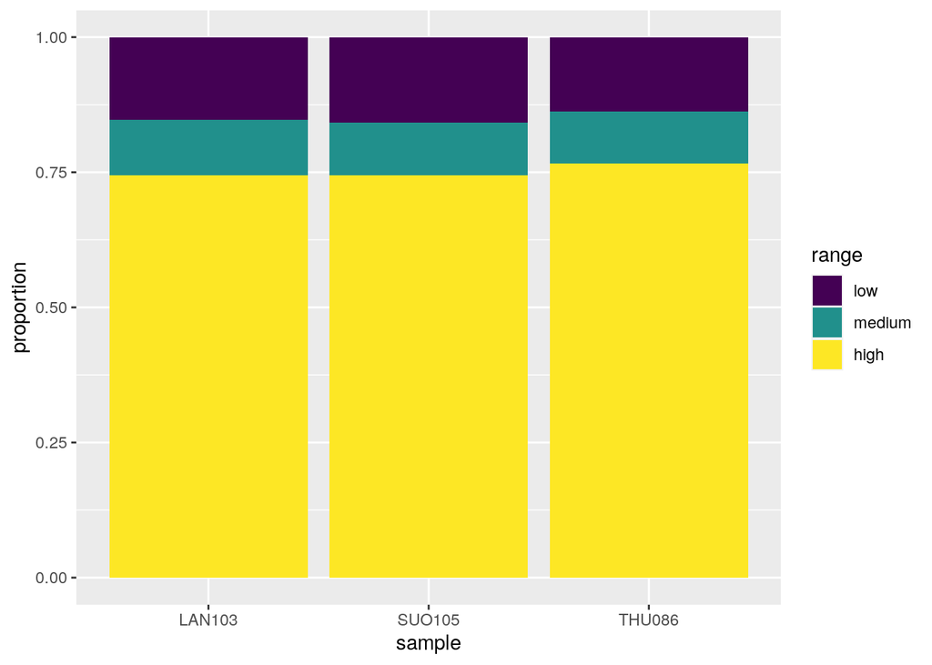

```r
mapqL <- pivot_longer(mapq, cols = 2:7,
                      names_to = c('sample', '.value'),
                      names_sep = '_')

mapqL$range <- factor('high', levels = c('low', 'medium', 'high'),
                      ordered = TRUE)
mapqL[mapqL$MAPQ < 60, 'range'] <- 'medium'
mapqL[mapqL$MAPQ < 40, 'range'] <- 'low'

mapqShort <- ddply(mapqL, .(range, sample),
                   summarize,
                   proportion = sum(proportion),
                   numReads   = sum(numReads))

ggplot(data = mapqShort,
       mapping = aes(x = sample, y = proportion, fill = range)) +
  geom_bar(stat = 'identity')
```

Reads from the same species as the reference (THU086) are only slightly better mapped than reads from distant species. In any case, it is worth keeping only the highest mapping quality in bam files.

# References

De-Kayne, R., O. M. Selz, D. A. Marques, D. Frei, O. Seehausen, and P. G. D. Feulner. 2022. “Genomic architecture of adaptive radiation and hybridization in Alpine whitefish.” *Nature Communications* 13: 4479. https://doi.org/10.1038/s41467-022-32181-8.